# Final checks

Anna Hutchinson

09/09/2019

### Final corrcoverage checks

The `corrcoverage` R package has been submitted and accepted to cran. To comply with cran’s checks, v1.1.0 removes the simGWAS dependency and the C++ function, `.zj_pp`.

In the README.md file, users are encouraged to download the github version which contains the simGWAS dependency and the C++ function (making the package slightly faster).

The master branch on github contains the complete version of the package (`v1.1.9000`) and the new_CRAN branch contains the version of the R package that is avaliable on cran (`v1.1.0`).

I have ran simulations to check the accuracy of results using the github and cran version of the packages.

#### Accuracy

The cran version of the package replaces the C++ code to calcualte the posterior probabilities of causality from the joint $Z$-score vectors with an equivalent R function. The results are expected to be the same (plus some error from the simulated ERR matrices) - but I double check this.

Great - the cran and github versions of the package give similar, accurate results.

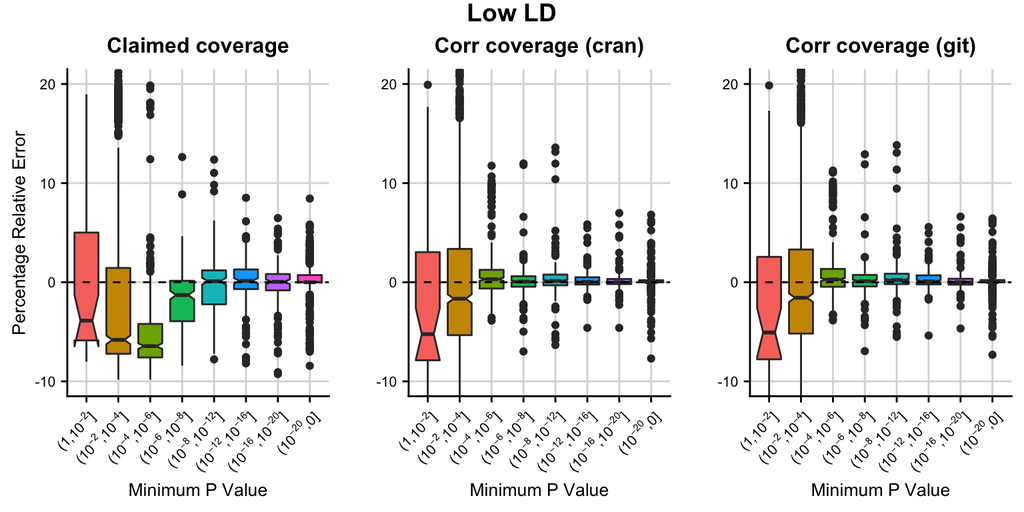

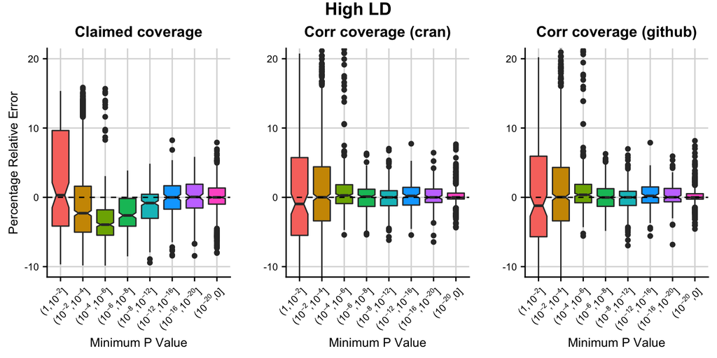

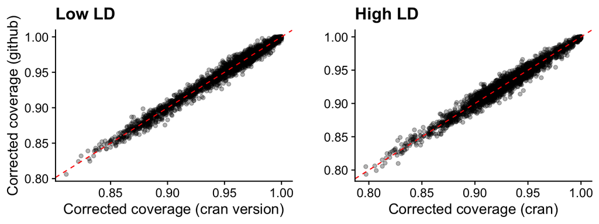

#### Timings

The timings using the cran and github version are similar, with the github version (with C++ code) being ~1 second faster for a 700 SNP region.